# Music_Genre_Detection_Final_Report

MIE1517 - Group Project

Group 7

1. Avinash Mudireddy
2. Nagarajan Jayaraman
3. Nehel Malhotra

Experimental results can be found here: https://github.com/nehelmalhotra/Music-Genre-Detection

Link to google colab notebook:

https://colab.research.google.com/drive/1XM5cBd9y4MAsHRLUbxcexLpg8U-wCNY1?usp=sharing

```python
# Install and import required libraries
!pip install mirdata
!pip install essentia-tensorflow
```

[output not shown]

```python
!pip install pydub audiomentations
```

```python
import torch
import torchaudio
import matplotlib.pyplot as plt
import matplotlib.image as mpimg
%matplotlib inline
import numpy as np
import pandas as pd
from pydub import AudioSegment
from random import randint
import plotly.figure_factory as ff

import os
import csv
from scipy.io.wavfile import write
import IPython
from getpass import getpass
from audiomentations import Compose, AddGaussianNoise, TimeStretch, PitchShift, Shift,TimeMask
import urllib
import librosa
import librosa.display

from torch.utils.data import random_split
random_seed = 42
torch.manual_seed(random_seed);
# Preprocessing
from sklearn.model_selection import train_test_split
from sklearn.preprocessing import LabelEncoder, StandardScaler
from sklearn.model_selection import StratifiedShuffleSplit
from sklearn.decomposition import PCA
from sklearn.svm import SVC
from sklearn.metrics import accuracy_score
from sklearn.metrics import confusion_matrix


from tqdm import tqdm
```

```python
import torch.nn as nn
import torch.nn.functional as F
from torch.utils.data import Dataset
from torchaudio.datasets import GTZAN
from torchaudio.datasets.utils import download_url
#from torchvision.datasets import ImageFolder
from torch.utils.data import DataLoader
import torchaudio.transforms as tt
from torch.autograd import Variable
from torchvision.datasets import ImageFolder
from torch.utils.data import Subset,Dataset, DataLoader, SubsetRandomSampler
from torchvision.transforms import Compose, ToTensor, Resize, Normalize
```

```python
import essentia.standard as es
import mirdata
import numpy as np

import json

from collections import Counter
from sklearn import preprocessing
```

### Obtain the dataset

```python
# The GTZAN dataset required for this classification task is available
# on torch_audio and can be downloaded as follows:
dataset = GTZAN(root=".", download=True)
```

```python
data_dir='/content/genres'
list_files=os.listdir(data_dir)
classes=[]
songs_per_class = {}
for file in list_files:
  name='{}/{}'.format(data_dir,file)
  counter = 0
  if os.path.isdir(name):
    classes.append(file)
    for songs in os.listdir(name):
      counter+=1
    songs_per_class[file] = counter
classes
```

```
['disco',
 'classical',
 'reggae',
 'jazz',
 'rock',
 'metal',
 'country',
 'hiphop',
 'blues',
 'pop']
```

```python
songs_per_class
```

```
{'blues': 100,
 'classical': 100,
 'country': 100,
 'disco': 100,
 'hiphop': 100,
 'jazz': 100,
 'metal': 100,
 'pop': 100,
 'reggae': 100,
 'rock': 100}
```

```python
waveform,samplerate,label= dataset[0]
print("shape of waveform {}, sample rate with {}, label is {} ".format(waveform.size(),samplerate,label))
```

```
shape of waveform torch.Size([1, 661794]), sample rate with 22050, label is blues
```

About the dataset:

The dataset consists of 100 songs each for 10 different music genres. These songs are all 30sec long and contain both vocals and instruments.

### Feature Extraction

Audio files such as .wav and .mp3 files contain audio signals that are represented by a wave. These audio files have two important parameters, the sampling rate which is how frequently the magnitute of the wave is captured and the bytes which is how much information is captured each time.

The GTZAN dataset consists of single-channel 16-bit audio data with a sampling rate of 22.05 kHz. However the magnitude of the wave themselves does not contain sufficient information and features need to be extracted from it in order to train a machine learning model.

We will be focusing of the following features and using these for model training:

1. Chromoa STFT
2. Amplitude Envelope
3. Amplitude RMSE
4. Spectral Centroid
5. Spectral Bandwidth
6. Spectral Rolloff
7. Spectral Contrast
8. Zero Crossing Rate
9. MFCC

A detailed description and analysis of each feature is provided in the following notebook:

https://github.com/nehelmalhotra/Music-Genre-Detection/blob/main/Music_Genre_Detection_EDA_Features.ipynb

In this section we will be focusing on presenting MFCC's.

Mel Frequency Cepstral Coefficients (MFCCs) of a signal are a small set of features which concisely describe the overall shape of a spectral envelope. Sincw MFCC's capture short-duration musical textures, these can be really useful when dealing with the music genre classification problem.

```python
## Extracting MFCC's and other features for an audio dataset


## The following funcion generates and saves a CSV file with all the audio information

def create_features(file_name,num_mfcc):
    header = 'filename chroma_stft rmse spectral_centroid spectral_bandwidth rolloff zero_crossing_rate'
    for i in range(1, num_mfcc+1):
        header += f' mfcc{i}'
    header += ' label'
    header = header.split()

    file = open(file_name, 'w', newline='')
    with file:
        writer = csv.writer(file)
        writer.writerow(header)
    genres = 'blues classical country disco hiphop jazz metal pop reggae rock'.split()

    for g in tqdm(genres):
        for filename in os.listdir(f'/content/genres/{g}'):
            try:
              songname = f'/content/genres/{g}/{filename}'
              # print(songname)
              y, sr = librosa.load(songname, mono=True, duration=30)
              chroma_stft = librosa.feature.chroma_stft(y=y, sr=sr)
              rmse = librosa.feature.rms(y=y)
              spec_cent = librosa.feature.spectral_centroid(y=y, sr=sr)
              spec_bw = librosa.feature.spectral_bandwidth(y=y, sr=sr)
              rolloff = librosa.feature.spectral_rolloff(y=y, sr=sr)
              # print(rolloff)
              zcr = librosa.feature.zero_crossing_rate(y)
              mfcc = librosa.feature.mfcc(y=y, sr=sr, n_mfcc=num_mfcc)
              to_append = f'{filename} {np.mean(chroma_stft)} {np.mean(rmse)} {np.mean(spec_cent)} {np.mean(spec_bw)} {np.mean(rolloff)} {np.mean(zcr)}'
              for e in mfcc:
                  to_append += f' {np.mean(e)}'
              to_append += f' {g}'
              file = open(file_name, 'a', newline='')
              with file:
                  # print("Writing to file")
                  writer = csv.writer(file)
                  writer.writerow(to_append.split())
            except (RuntimeError,IsADirectoryError):
              pass
```

```python
create_features('mfcc_20.csv',20)
```

### Data Splitting

Deep learning and neural networks have been known about for years but the wide adoption of these have also started a few years ago. This is because these techniques are very reliant on the quality and also quantity of data.

Data quantity when dealing with audio data can be increased by splitting an audio files into multiple segments. This also ensures that different sections of a given song also still percieved as a given genre.

```python
def export_to_dir(file_name,chopped_audio,counter):
  for audio_data in chopped_audio:
    save_file_name=file_name + '_' + str(counter)+'.wav'
    # export_path=os.path.join(new_dir,file_name)
    audio_data.export(save_file_name,format="wav")
    # print(type(abc))
    int(counter)
    counter+=1
  return counter

def chop_audio(audio_file,segment_size,max_size):  #All file are not even so we cut it in same size using max_size and provide segment size using segment
  audio_data = AudioSegment.from_file(audio_file)
  cut_audio_data = audio_data[:max_sec]
  chopped_audio=[x for x in cut_audio_data[::segment]]
  return chopped_audio


max_sec=25 * 1000 # max size of audio we take (for 25 sec)
segment=5 * 1000  # segment size(for 5 sec)
new_dir='/content/data'
counter=0
```

```python
genres = 'blues classical country disco hiphop jazz metal pop reggae rock'.split()
features=[]
labels=[]
file_names = []
for g in tqdm(genres):
    counter = 0
    directory = f'/content/data_seg/{g}'
    if not os.path.exists(directory):
        os.makedirs(directory)
    for filename in os.listdir(f'/content/genres/{g}'):
        songname = f'/content/genres/{g}/{filename}'
        chopped_audio=chop_audio(songname,segment,max_sec)
        file_name = directory = f'/content/data_seg/{g}/{g}'
        # print(file_name)
        counter=export_to_dir(file_name,chopped_audio,counter)
```

### Data Augmentations

Data augmentation can not only be used to create additional data, but it also introduces variations and noise to the exisiting data which can help a machine learning model to generalize better. For our audio dataset, we will be using the following augmentations, each with a 30% probability:

1. Introduce gaussian noise.
2. Time stretching.
3. Shifting the pitch.
4. Make a randomly chosen part of the audio silent.

```python
augment = Compose([
    AddGaussianNoise(min_amplitude=0.01, max_amplitude=0.05, p=0.3),
    TimeStretch(min_rate=0.5, max_rate=1, p=0.3),
    PitchShift(min_semitones=-4, max_semitones=4, p=0.3),
    TimeMask(min_band_part=0.0, max_band_part=0.1,p=0.3)
])
```

```python
def make_augmentations(file_name,save_dir):
    w,samplerate = librosa.load(file_name)
    augmented_samples = augment(samples=w, sample_rate=22050)
    # os.chdir(save_dir)
    write(os.path.join(save_dir,file_name), samplerate, augmented_samples.astype(np.float32))

audio_data_path = "/content/data_seg"
aug_data_path = "/content/data_seg_aug"
if not os.path.exists(aug_data_path):
    os.mkdir(aug_data_path)

for x in tqdm(classes):
  source_path=os.path.join(audio_data_path, x)
  dest_path = os.path.join(aug_data_path, x)
  if not os.path.exists(dest_path):
      os.mkdir(dest_path)
  list_file=os.listdir(source_path)
  os.chdir(source_path)
  for file_name in list_file:
    make_augmentations(file_name,dest_path)
```

### Baseline Model

A baselines model is used as a reference point as something that is easy to implement and train. For this multiclass classification problem, we will be using a SVM model as the baseline.

```python
df = pd.read_csv('/content/mfcc_20.csv')
```

```python
df.head()
```

|  | filename | chroma_stft | rmse | spectral_centroid | spectral_bandwidth | rolloff | zero_crossing_rate | mfcc1 | mfcc2 | mfcc3 | mfcc4 | mfcc5 | mfcc6 | mfcc7 | mfcc8 | mfcc9 | mfcc10 | mfcc11 | mfcc12 | mfcc13 | mfcc14 | mfcc15 | mfcc16 | mfcc17 | mfcc18 | mfcc19 | mfcc20 | label |
| --- | --- | --- | --- | --- | --- | --- | --- | --- | --- | --- | --- | --- | --- | --- | --- | --- | --- | --- | --- | --- | --- | --- | --- | --- | --- | --- | --- | --- |
| 0 | blues.00027.wav | 0.288721 | 0.095768 | 1391.367710 | 1494.892439 | 2811.108002 | 0.072359 | -228.227997 | 130.353546 | -23.297619 | 70.173668 | 1.137059 | 7.609718 | 0.915007 | 1.989320 | -6.161291 | -9.390744 | -2.566143 | -4.523861 | -0.266735 | 0.181102 | -1.513058 | 1.460951 | -6.976431 | -8.318999 | 4.241007 | 0.979682 | blues |
| 1 | blues.00096.wav | 0.260574 | 0.051349 | 1132.340629 | 1582.492047 | 2065.479177 | 0.048314 | -314.582794 | 139.926743 | 11.865850 | 30.113317 | -7.549764 | 14.914179 | -2.699563 | 6.707931 | -6.391602 | 2.819350 | -11.715414 | 2.077480 | -11.442501 | -9.504389 | -15.185495 | -9.355572 | -5.672771 | 1.564773 | 0.890936 | -7.960377 | blues |
| 2 | blues.00014.wav | 0.329163 | 0.066981 | 1172.065695 | 1705.817502 | 2344.952487 | 0.045046 | -305.705170 | 113.060928 | 12.118721 | 45.030003 | 17.769758 | 14.579918 | 4.166732 | 0.225274 | -7.021748 | 13.644271 | 8.934528 | 1.298479 | 5.954477 | 8.543867 | 1.117664 | 0.591559 | 0.057474 | -3.712341 | -1.004448 | -1.802434 | blues |
| 3 | blues.00099.wav | 0.370279 | 0.105061 | 1538.817338 | 1703.507382 | 3175.272466 | 0.074799 | -177.165863 | 136.221588 | -26.915182 | 36.376289 | -18.760828 | 20.909632 | -1.778092 | 3.013012 | -5.600873 | 5.638467 | -8.117091 | 5.642528 | -10.790227 | -2.416264 | -6.943611 | -2.507238 | -5.203642 | -3.407661 | -3.246502 | -2.681821 | blues |
| 4 | blues.00032.wav | 0.276317 | 0.101234 | 1309.424564 | 1882.919367 | 2764.099953 | 0.039393 | -288.801727 | 105.899620 | 18.791321 | 23.688492 | 5.705112 | 25.549154 | -13.467205 | 12.424733 | -11.943818 | 1.575499 | -15.636262 | -6.665247 | -11.718801 | -2.952338 | -7.380499 | -15.693589 | -10.958548 | -10.877396 | -18.504187 | -19.110741 | blues |

```python
spectra = df.iloc[:,1:]
spectra = spectra.drop('label',axis=1)
label = df['label']
```

```python
spectra.shape
```

```
(1000, 26)
```

```python
x_train,x_test,y_train,y_test = train_test_split(spectra,label,test_size = 0.2,stratify = label)
```

```python
encoded = {'pop':0,'jazz':1,'blues':2,'reggae':3,'classical':4,'metal':5,'country':6,'hiphop':7,'rock':8,'disco':9}
y_train = y_train.map(encoded)
y_test = y_test.map(encoded)
```

```python
clf = SVC(C=0.1, cache_size=200, class_weight=None, coef0=1000.0,
          decision_function_shape='ovr', degree=2, gamma=0.0001, kernel='linear',
          max_iter=-1, probability=False, random_state=None, shrinking=True,
          tol=0.001, verbose=False)

clf.fit(x_train, y_train)
```

```
SVC(C=0.1, coef0=1000.0, degree=2, gamma=0.0001, kernel='linear')
```

```python
train_predictions = clf.predict(x_train)
test_predictions = clf.predict(x_test)

print("Train Accuracy: " ,accuracy_score(train_predictions, y_train))
print("Test Accuracy:" ,accuracy_score(test_predictions, y_test))
```

```
Train Accuracy:  0.79
Test Accuracy: 0.56
```

### Neural Network Models

We will now attempt to train a neural network model for the audio classification task and will try different architectures such as MLP, LSTM, CNN's ,etc.

#### ANN

```python
class simpleANN(nn.Module):
    def __init__(self):
        super(simpleANN, self).__init__()
        self.name = "simple"
        self.fc1 = nn.Linear(26, 100)
        self.fc2 = nn.Linear(100, 20)
        self.fc3 = nn.Linear(20, 10)

    def forward(self, x):
        x = x.view(-1, 26)
        x = F.relu(self.fc1(x))
        x = F.relu(self.fc2(x))
        x = self.fc3(x)
        return x
```

```python
# df = pd.read_csv('/content/data_aug_13mfcc.csv')
# spectra = df.iloc[:,1:]
# spectra = spectra.drop('label',axis=1)
# label = df['label']
# print(spectra.shape)
# x_train,x_test,y_train,y_test = train_test_split(spectra,label,test_size = 0.2,stratify = label)
# encoded = {'pop':0,'jazz':1,'blues':2,'reggae':3,'classical':4,'metal':5,'country':6,'hiphop':7,'rock':8,'disco':9}
# y_train = y_train.map(encoded)
# y_test = y_test.map(encoded)
```

[output not shown]

```python
ytrain = (torch.tensor(y_train.values))
ytest = (torch.tensor(y_test.values))
```

```python
train = torch.utils.data.TensorDataset(torch.tensor(x_train.values),ytrain)
test = torch.utils.data.TensorDataset(torch.tensor(x_test.values),ytest)
```

```python
train_loader = torch.utils.data.DataLoader(train, batch_size = 128, shuffle = True)
test_loader = torch.utils.data.DataLoader(test, batch_size = 128, shuffle = True)
```

```python
def train_network(model, train_loader, valid_loader, num_epochs=100, learning_rate=1e-4):
    criterion = nn.CrossEntropyLoss()
    optimizer = torch.optim.Adam(model.parameters(), lr=learning_rate)
    losses, train_acc, valid_acc = [], [], []
    epochs,iters = [],[]
    n = 0
    for epoch in range(num_epochs):
        print('Epoch {}/{}'.format(epoch, num_epochs - 1))
        print('-' * 10)
        for audio, labels in train_loader:
            if use_cuda and torch.cuda.is_available():
              audio = audio.cuda()
              labels = labels.cuda()
            optimizer.zero_grad()
            # print(audio.shape)
            # print("Labels shape",labels.shape)
            pred = model(audio.float()).squeeze(0)
            # print("Model prediction:",pred)
            # print("Model prediction Shape:",pred.shape)
            loss = criterion(pred, labels)
            loss.backward()
            optimizer.step()
            n += 1
        iters.append(n)
        losses.append(float(loss))
        if epoch % 5 == 4:
            epochs.append(epoch)
            train_acc.append(get_accuracy(model, train_loader))
            valid_acc.append(get_accuracy(model, valid_loader))
            print("Epoch %d; Loss %f; Train Acc %f; Val Acc %f" % (
                epoch+1, losses[-1], train_acc[-1], valid_acc[-1]))

    plt.title("Training Curve")
    plt.plot(iters, losses, label="Train")
    plt.xlabel("Iterations")
    plt.ylabel("Loss")
    plt.show()

    plt.title("Training Curve")
    plt.plot(epochs, train_acc, label="Train")
    plt.plot(epochs, valid_acc, label="Validation")
    plt.xlabel("Iterations")
    plt.ylabel("Training Accuracy")
    plt.legend(loc='best')
    plt.show()

    return model

def get_accuracy(model, data_loader):
    correct, total = 0, 0
    for audio, labels in data_loader:
        if use_cuda and torch.cuda.is_available():
            audio = audio.cuda()
            labels = labels.cuda()
        output = model(audio.float()).squeeze(0)
        pred = output.max(1, keepdim=True)[1]
        correct += pred.eq(labels.view_as(pred)).sum().item()
        total += labels.shape[0]
    return correct / total
```

```
----------
----------
----------
----------
----------
Epoch 5; Loss 44.391201; Train Acc 0.167500; Val Acc 0.180000
----------
----------
----------
----------
----------
Epoch 10; Loss 22.375528; Train Acc 0.105000; Val Acc 0.130000
----------
----------
----------
----------
----------
Epoch 15; Loss 7.174352; Train Acc 0.146250; Val Acc 0.150000
----------
----------
----------
----------
----------
Epoch 20; Loss 8.258859; Train Acc 0.201250; Val Acc 0.210000
----------
----------
----------
----------
----------
Epoch 25; Loss 4.608345; Train Acc 0.236250; Val Acc 0.225000
----------
----------
----------
----------
----------
Epoch 30; Loss 3.823028; Train Acc 0.277500; Val Acc 0.275000
----------
----------
----------
----------
```

[output cut: 2345 more lines]

```
----------
----------
Epoch 1990; Loss 0.964769; Train Acc 0.663750; Val Acc 0.565000
----------
----------
----------
----------
----------
Epoch 1995; Loss 0.675335; Train Acc 0.662500; Val Acc 0.575000
----------
----------
----------
----------
----------
Epoch 2000; Loss 1.030969; Train Acc 0.648750; Val Acc 0.575000
```

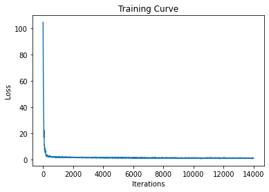

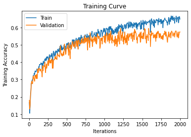

```python
use_cuda = True
net = simpleANN()
model = train_network(net,train_loader,test_loader,num_epochs=2000,learning_rate=0.0001)
```

#### LSTM

```python
class RNN(nn.Module):
    def __init__(self, input_size, hidden_size, num_layers, num_classes):
        super(RNN, self).__init__()
        self.num_layers = num_layers
        self.hidden_size = hidden_size
        self.lstm = nn.LSTM(input_size, hidden_size, num_layers, dropout=0.5,batch_first=True)
        self.fc1 = nn.Linear(hidden_size, hidden_size)
        self.relu = nn.ReLU()
        self.fc = nn.Linear(hidden_size, num_classes)

    def forward(self, x):
        # x = x.unsqueeze(0)
        # print("Input Shape",x.shape)
        # print(x.size)
        h0 = Variable(torch.zeros(self.num_layers, x.size(0), self.hidden_size).float()).cuda()
        c0 = Variable(torch.zeros(self.num_layers, x.size(0), self.hidden_size).float()).cuda()
        # print("Initial state shape:",h0.shape)
        out, _ = self.lstm(x, (h0, c0))
        # print("LSTM Output Shape:",out.shape)
        out = self.relu(self.fc1(torch.max(out, dim=1)[0]))
        # out = self.relu(self.fc1(out[:, -1, :]))
        out = self.fc(out)
        return out
```

When training on LSTM's, we will be using only the MFCC features. Also, instead of averaging the mfcc per frame, we will use the entire set of coefficients instead.

```python
genres = 'blues classical country disco hiphop jazz metal pop reggae rock'.split()
features=[]
labels=[]
file_names = []
for g in tqdm(genres):
    for filename in os.listdir(f'/content/genres/{g}'):
        try:
          songname = f'/content/genres/{g}/{filename}'
          # print(songname)
          y, sr = librosa.load(songname, mono=True, duration=25)
          mfcc = librosa.feature.mfcc(y=y, sr=sr, n_mfcc=20)
          features.append(mfcc[...,np.newaxis])
          labels.append(g)
          file_names.append(filename)
        except (RuntimeError,IsADirectoryError):
          pass
```

```python
output= np.concatenate(features,axis=2)
output = output.transpose(2,1,0)
output.shape
```

```
(1000, 1077, 20)
```

```python
x_train,x_test,y_train,y_test = train_test_split(output,labels,test_size = 0.3,stratify = labels)
```

```python
encoded = {'pop':0,'jazz':1,'blues':2,'reggae':3,'classical':4,'metal':5,'country':6,'hiphop':7,'rock':8,'disco':9}
y_train = pd.Series(y_train).map(encoded)
y_test = pd.Series(y_test).map(encoded)
```

```python
x_train.shape
```

```
(700, 1077, 20)
```

```python
# Make training and validation dataset in format usable by dataloader

train = []
for i in range(len(x_train)):
    train.append((torch.Tensor(list(x_train[i,:,:])),y_train.values[i]))

valid = []
for i in range(len(x_test)):
    valid.append((torch.Tensor(list(x_test[i,:,:])),y_test.values[i]))
```

```python
#Dataloader
train_loader = torch.utils.data.DataLoader(train, batch_size=256, shuffle=True)
valid_loader = torch.utils.data.DataLoader(valid, batch_size=256, shuffle=True)
```

```python
song,label = next(iter(train_loader))
song.shape
```

```
torch.Size([256, 1077, 20])
```

```
Training on Cuda
----------
----------
----------
----------
----------
Epoch 5; Loss 2.257578; Train Acc 0.258571; Val Acc 0.263333
----------
----------
----------
----------
----------
Epoch 10; Loss 2.162968; Train Acc 0.320000; Val Acc 0.350000
----------
----------
----------
----------
----------
Epoch 15; Loss 1.931310; Train Acc 0.338571; Val Acc 0.353333
----------
----------
----------
----------
----------
Epoch 20; Loss 1.753049; Train Acc 0.380000; Val Acc 0.380000
----------
----------
----------
----------
----------
Epoch 25; Loss 1.645903; Train Acc 0.431429; Val Acc 0.380000
----------
----------
----------
----------
----------
Epoch 30; Loss 1.535754; Train Acc 0.434286; Val Acc 0.366667
----------
----------
----------
```

[output cut: 66 more lines]

```
----------
----------
Epoch 90; Loss 0.697195; Train Acc 0.782857; Val Acc 0.536667
----------
----------
----------
----------
----------
Epoch 95; Loss 0.668254; Train Acc 0.804286; Val Acc 0.516667
----------
----------
----------
----------
----------
Epoch 100; Loss 0.662467; Train Acc 0.781429; Val Acc 0.500000
```

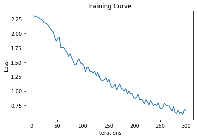

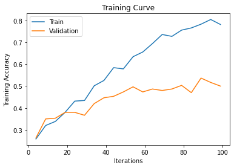

```python
use_cuda = True
rnn = RNN(input_size=20, hidden_size=50, num_layers=2, num_classes=10)
CUDA_LAUNCH_BLOCKING=1
if use_cuda and torch.cuda.is_available():
  print("Training on Cuda")
  rnn.cuda()

model = train_network(rnn,train_loader,valid_loader,num_epochs=100,learning_rate=1e-3)
```

#### CNN

Even though audio dataset is usually only thought of as waves and/or a series of numbers based on their Mel frequencies, there is another way of representing audio data that enables us to use better use CNN models for training a classifier.

These representations are called spectograms. These are obtained by converting the audio data from time domain to frequency domain by computing Short-term Fourier Transforms and then plotting the altitudes on logarithmic scale.

```python
genres = 'blues classical country disco hiphop jazz metal pop reggae rock'.split()
for g in genres:
  save_dir = f'/content/genres_images/{g}/'
  if not os.path.exists(save_dir):
    os.makedirs(save_dir)
```

```python
base_loc = '/content/genres/'
genres = 'blues classical country disco hiphop jazz metal pop reggae rock'.split()
for g in genres:
    for filename in os.listdir(f'/content/genres/{g}'):
        try:
          songname = f'/content/genres/{g}/{filename}'
          wave, sr = librosa.load(songname, mono=True, duration=30)
          mfccs = librosa.feature.mfcc(wave,n_fft = 2048, hop_length = 512, n_mfcc= 20)
          plt.figure(figsize = (18, 5))
          librosa.display.specshow(mfccs, sr= sr, hop_length= 512)
          # Create the outputs folder if not created already
          save_dir = f'/content/genres_images/{g}/'
          if not os.path.exists(save_dir):
            os.makedirs(save_dir)
          nw_fn = filename.split('.wav')[0]
          plt.savefig(save_dir+nw_fn+'.png')
          plt.close()
        except:
          print("Error with"+filename)
```

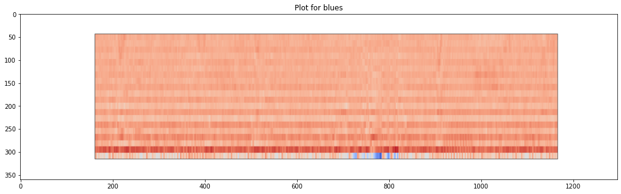

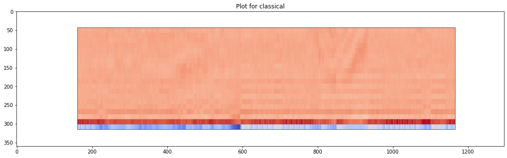

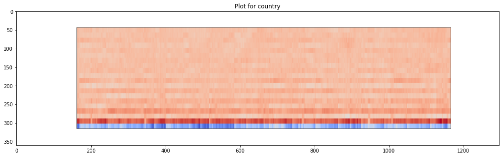

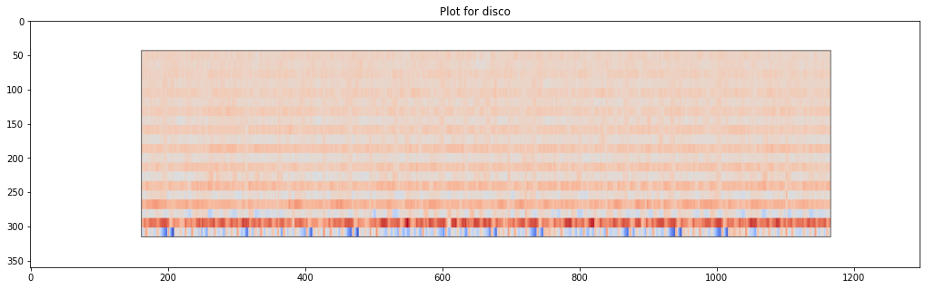

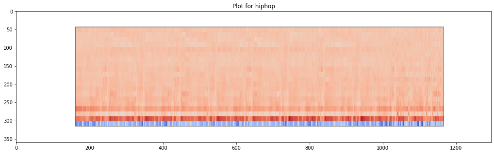

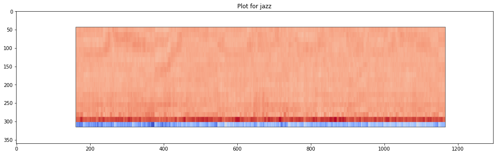

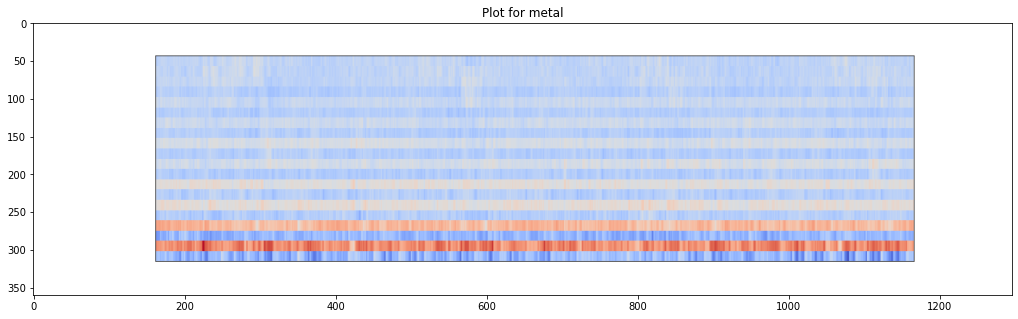

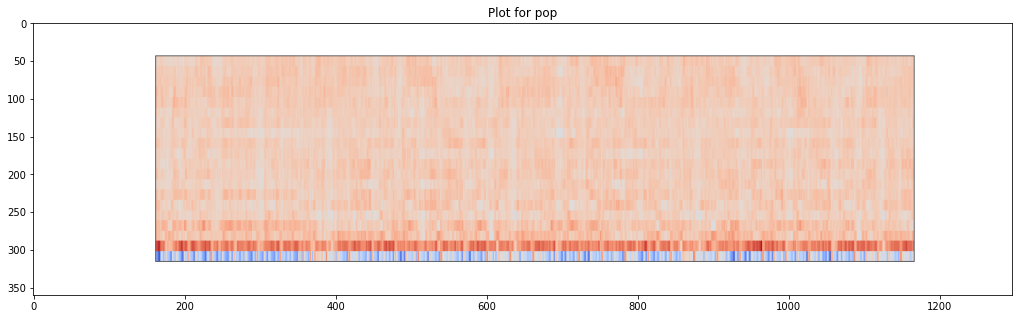

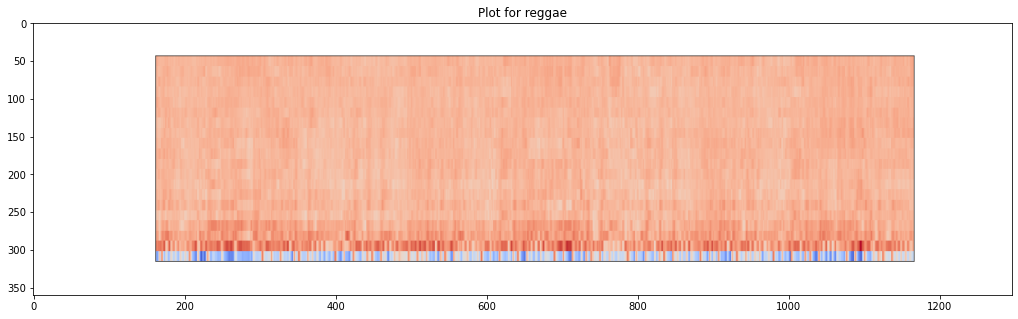

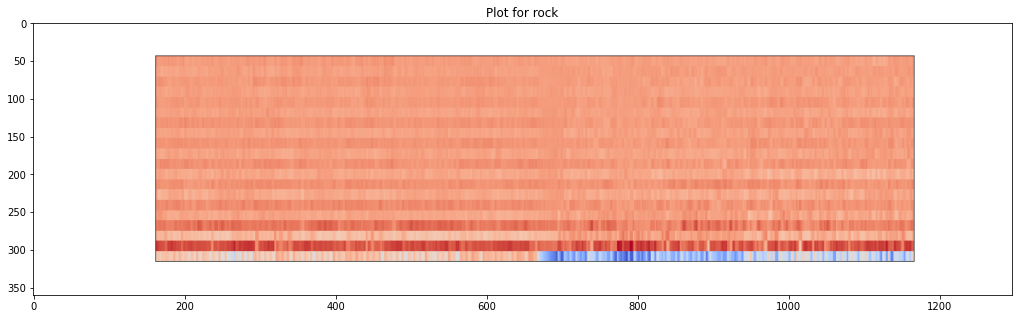

```python
for g in genres:
  num = f"{g}."+str(randint(0, 100)).zfill(5)
  img = mpimg.imread(f'/content/genres_images/{g}/{num}.png')
  plt.figure(figsize = (18, 5))
  imgplot = plt.imshow(img)
  plt.title(f"Plot for {g}")
  plt.show()
```

```python
class ConvNet(nn.Module):

  def __init__(self, kernel = [3,3,5]):

    super(ConvNet, self).__init__()
    self.feature_extractor = nn.Sequential(
      nn.Conv2d(in_channels=3, out_channels=8, kernel_size=kernel[0]),
      nn.ReLU(),
      nn.MaxPool2d(2,2),
      nn.Conv2d(in_channels=8, out_channels=12, kernel_size=kernel[1]),
      nn.ReLU(),
      nn.MaxPool2d(2,2),
      nn.Conv2d(in_channels=12, out_channels=24, kernel_size=kernel[2]),
      nn.ReLU(),
      nn.MaxPool2d(2,2),
      nn.Flatten())
    self.name = 'CNN'

    n_channels = self.feature_extractor(torch.empty(1, 3, 224, 224)).size(-1)

    self.classifier = nn.Sequential(
        nn.Linear(n_channels, 32),
        nn.Linear(32, 10))

  def forward(self, x):
    features = self.feature_extractor(x)
    out = self.classifier(features)
    return out
```

```python
def train_split_dataset(dataset,name,split_size=0.20):
    train_idx, val_idx = train_test_split(list(range(len(dataset))), test_size=split_size)
    datasets['train'] = Subset(dataset, train_idx)
    datasets[name] = Subset(dataset, val_idx)
    return datasets

target_classes = ['reggae','rock','blues','classical','country','disco','hiphop','jazz','metal','pop']

datasets = {}
dataset = ImageFolder('/content/genres_images', transform=Compose([Resize((224,224)),ToTensor()]))
print("Total no. of imgaes in the dataset loaded is:",len(dataset))
datasets = train_split_dataset(dataset,'test',split_size=0.25)
datasets = train_split_dataset(datasets['train'],'val')

#75:25 training vs test split
#20 percent of training is validation split
print("Total No. of training images are:",len(datasets['train']))
print("Total no. of validation images are:",len(datasets['val']))
print("Total no. of test images are:",len(datasets['test']))
```

```
Total no. of imgaes in the dataset loaded is: 1000
Total No. of training images are: 600
Total no. of validation images are: 150
Total no. of test images are: 250
```

```python
def train(model, train_dataset, val_dataset, batch_size=128, num_epochs=20, learn_rate=0.001):
    torch.manual_seed(4)

    criterion = nn.CrossEntropyLoss()
    optimizer = torch.optim.Adam(model.parameters(), lr=learn_rate)
    print('Loading data......')
    train_loader = torch.utils.data.DataLoader(train_dataset,
                                               batch_size=batch_size,
                                               shuffle=True)

    val_loader = torch.utils.data.DataLoader(val_dataset,
                                             batch_size=batch_size,
                                             shuffle=True)
    print('Data loaded..!')
    train_acc = np.zeros(num_epochs)
    val_acc = np.zeros(num_epochs)
    iters,losses = [], []
    n = 0
    for epoch in range(num_epochs):

        for imgs, labels in iter(train_loader):

            if use_cuda and torch.cuda.is_available():
              imgs = imgs.cuda()
              labels = labels.cuda()

            out = model(imgs)             # forward pass
            loss = criterion(out, labels) # compute the total loss
            loss.backward()               # backward pass (compute parameter updates)
            optimizer.step()              # make the updates for each parameter
            optimizer.zero_grad()         # a clean up step for PyTorch
            n += 1

        # save the current training information
        iters.append(n)

        losses.append(float(loss)/batch_size)   # compute *average* loss

        # track accuracy
        train_acc[epoch] = get_accuracy(model, train_loader)
        val_acc[epoch] = get_accuracy(model, val_loader)

        print(("Epoch : {}/{} , Training acc: {} , Validation acc: {}").format(epoch, num_epochs,train_acc[epoch], val_acc[epoch]))

    plt.title("Training Curve")
    plt.plot(iters, losses, label="Train")
    plt.xlabel("Iterations")
    plt.ylabel("Loss")
    plt.show()

    plt.title("Training Curve")
    plt.plot(iters, train_acc, label="Train")
    plt.plot(iters, val_acc, label="Validation")
    plt.xlabel("Iterations")
    plt.ylabel("Training Accuracy")
    plt.legend(loc='best')
    plt.show()

    print("Final Training Accuracy: {}".format(train_acc[-1]))
    print("Final Validation Accuracy: {}".format(val_acc[-1]))
```

```python
def get_accuracy(model, data_loader):
    correct = 0
    total = 0
    #print('entered accuracy')
    for imgs, labels in data_loader:

        if use_cuda and torch.cuda.is_available():
          imgs = imgs.cuda()
          labels = labels.cuda()

        output = model(imgs)
        #select index with maximum prediction score
        pred = output.max(1, keepdim=True)[1]
        correct += pred.eq(labels.view_as(pred)).sum().item()
        total += imgs.shape[0]
    return correct / total
```

```
Loading data......
Data loaded..!
Epoch : 0/50 , Training acc: 0.16833333333333333 , Validation acc: 0.18666666666666668
Epoch : 1/50 , Training acc: 0.14166666666666666 , Validation acc: 0.12666666666666668
Epoch : 2/50 , Training acc: 0.20666666666666667 , Validation acc: 0.21333333333333335
Epoch : 3/50 , Training acc: 0.2 , Validation acc: 0.20666666666666667
Epoch : 4/50 , Training acc: 0.255 , Validation acc: 0.26666666666666666
Epoch : 5/50 , Training acc: 0.245 , Validation acc: 0.23333333333333334
Epoch : 6/50 , Training acc: 0.3383333333333333 , Validation acc: 0.32666666666666666
Epoch : 7/50 , Training acc: 0.32666666666666666 , Validation acc: 0.32
Epoch : 8/50 , Training acc: 0.3566666666666667 , Validation acc: 0.4
Epoch : 9/50 , Training acc: 0.3566666666666667 , Validation acc: 0.3933333333333333
Epoch : 10/50 , Training acc: 0.36666666666666664 , Validation acc: 0.4
Epoch : 11/50 , Training acc: 0.38 , Validation acc: 0.4066666666666667
Epoch : 12/50 , Training acc: 0.44166666666666665 , Validation acc: 0.4
Epoch : 13/50 , Training acc: 0.3983333333333333 , Validation acc: 0.4533333333333333
Epoch : 14/50 , Training acc: 0.42833333333333334 , Validation acc: 0.4266666666666667
Epoch : 15/50 , Training acc: 0.4266666666666667 , Validation acc: 0.4666666666666667
Epoch : 16/50 , Training acc: 0.42833333333333334 , Validation acc: 0.44
Epoch : 17/50 , Training acc: 0.4116666666666667 , Validation acc: 0.3933333333333333
Epoch : 18/50 , Training acc: 0.46 , Validation acc: 0.5
Epoch : 19/50 , Training acc: 0.47 , Validation acc: 0.4666666666666667
Epoch : 20/50 , Training acc: 0.445 , Validation acc: 0.42
Epoch : 21/50 , Training acc: 0.5033333333333333 , Validation acc: 0.4866666666666667
Epoch : 22/50 , Training acc: 0.45666666666666667 , Validation acc: 0.44666666666666666
Epoch : 23/50 , Training acc: 0.45666666666666667 , Validation acc: 0.44666666666666666
Epoch : 24/50 , Training acc: 0.5266666666666666 , Validation acc: 0.5066666666666667
Epoch : 25/50 , Training acc: 0.48333333333333334 , Validation acc: 0.4866666666666667
Epoch : 26/50 , Training acc: 0.5033333333333333 , Validation acc: 0.49333333333333335
Epoch : 27/50 , Training acc: 0.5283333333333333 , Validation acc: 0.5
Epoch : 28/50 , Training acc: 0.5333333333333333 , Validation acc: 0.52
Epoch : 29/50 , Training acc: 0.5366666666666666 , Validation acc: 0.5
Epoch : 30/50 , Training acc: 0.56 , Validation acc: 0.54
Epoch : 31/50 , Training acc: 0.48333333333333334 , Validation acc: 0.47333333333333333
Epoch : 32/50 , Training acc: 0.5633333333333334 , Validation acc: 0.4866666666666667
Epoch : 33/50 , Training acc: 0.5816666666666667 , Validation acc: 0.54
Epoch : 34/50 , Training acc: 0.5866666666666667 , Validation acc: 0.5333333333333333
Epoch : 35/50 , Training acc: 0.5783333333333334 , Validation acc: 0.5266666666666666
Epoch : 36/50 , Training acc: 0.595 , Validation acc: 0.5466666666666666
Epoch : 37/50 , Training acc: 0.565 , Validation acc: 0.5533333333333333
Epoch : 38/50 , Training acc: 0.5633333333333334 , Validation acc: 0.5
Epoch : 39/50 , Training acc: 0.585 , Validation acc: 0.5266666666666666
Epoch : 40/50 , Training acc: 0.5766666666666667 , Validation acc: 0.5666666666666667
Epoch : 41/50 , Training acc: 0.5966666666666667 , Validation acc: 0.5466666666666666
Epoch : 42/50 , Training acc: 0.5866666666666667 , Validation acc: 0.5266666666666666
Epoch : 43/50 , Training acc: 0.6183333333333333 , Validation acc: 0.5733333333333334
Epoch : 44/50 , Training acc: 0.595 , Validation acc: 0.5466666666666666
Epoch : 45/50 , Training acc: 0.6033333333333334 , Validation acc: 0.5466666666666666
Epoch : 46/50 , Training acc: 0.645 , Validation acc: 0.58
Epoch : 47/50 , Training acc: 0.6083333333333333 , Validation acc: 0.5
Epoch : 48/50 , Training acc: 0.6716666666666666 , Validation acc: 0.5933333333333334
Epoch : 49/50 , Training acc: 0.67 , Validation acc: 0.6
```

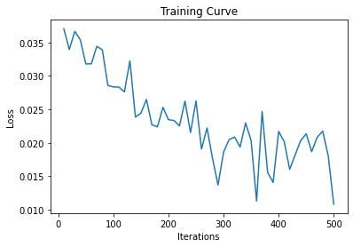

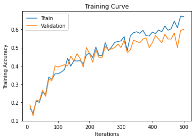

```
Final Training Accuracy: 0.67
Final Validation Accuracy: 0.6
```

```python
torch.cuda.empty_cache()
use_cuda = True
CNN = ConvNet()
if use_cuda and torch.cuda.is_available():
  CNN.cuda()

#lr=0.001,BS=32,epoch=20,stride=[3,3,5]
train(CNN, datasets['train'], datasets['val'],batch_size=64,num_epochs=50)
```

#### Training on 5 sec segments and augmented data

```python
genres = 'blues classical country disco hiphop jazz metal pop reggae rock'.split()
features=[]
labels=[]
file_names = []
for g in tqdm(genres):
    for filename in os.listdir(f'/content/data_seg_aug/{g}'):
        try:
          songname = f'/content/data_seg_aug/{g}/{filename}'
          # print(songname)
          y, sr = librosa.load(songname, mono=True, duration=25)
          mfcc = librosa.feature.mfcc(y=y, sr=sr, n_mfcc=20)
          features.append(mfcc[...,np.newaxis])
          labels.append(g)
          file_names.append(filename)
        except (RuntimeError,IsADirectoryError):
          pass
```

```python
output= np.concatenate(features,axis=2)
output = output.transpose(2,1,0)
output.shape
```

```
(5000, 216, 20)
```

```python
x_train,x_test,y_train,y_test = train_test_split(output,labels,test_size = 0.3,stratify = labels)
```

```python
encoded = {'pop':0,'jazz':1,'blues':2,'reggae':3,'classical':4,'metal':5,'country':6,'hiphop':7,'rock':8,'disco':9}
y_train = pd.Series(y_train).map(encoded)
y_test = pd.Series(y_test).map(encoded)
```

```python
# Make training and validation dataset in format usable by dataloader

train = []
for i in range(len(x_train)):
    train.append((torch.Tensor(list(x_train[i,:,:])),y_train.values[i]))

valid = []
for i in range(len(x_test)):
    valid.append((torch.Tensor(list(x_test[i,:,:])),y_test.values[i]))

train_loader = torch.utils.data.DataLoader(train, batch_size=512, shuffle=True)
valid_loader = torch.utils.data.DataLoader(valid, batch_size=512, shuffle=True)
```

```
Training on Cuda
----------
----------
----------
----------
----------
Epoch 5; Loss 2.294484; Train Acc 0.143714; Val Acc 0.136667
----------
----------
----------
----------
----------
Epoch 10; Loss 2.286360; Train Acc 0.175714; Val Acc 0.170667
----------
----------
----------
----------
----------
Epoch 15; Loss 2.268953; Train Acc 0.197714; Val Acc 0.180667
----------
----------
----------
----------
----------
Epoch 20; Loss 2.243893; Train Acc 0.237143; Val Acc 0.222667
----------
----------
----------
----------
----------
Epoch 25; Loss 2.193815; Train Acc 0.301714; Val Acc 0.276000
----------
----------
----------
----------
----------
Epoch 30; Loss 2.135625; Train Acc 0.294286; Val Acc 0.280667
----------
----------
----------
```

[output cut: 546 more lines]

```
----------
----------
Epoch 490; Loss 1.021245; Train Acc 0.628286; Val Acc 0.506667
----------
----------
----------
----------
----------
Epoch 495; Loss 1.029765; Train Acc 0.636286; Val Acc 0.500667
----------
----------
----------
----------
----------
Epoch 500; Loss 1.107278; Train Acc 0.638286; Val Acc 0.502667
```

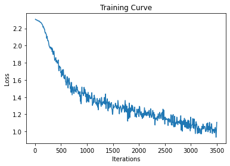

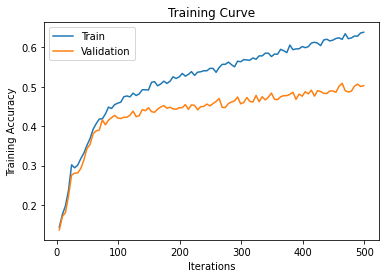

```python
use_cuda = True
rnn = RNN(input_size=20, hidden_size=50, num_layers=2, num_classes=10)
CUDA_LAUNCH_BLOCKING=1
if use_cuda and torch.cuda.is_available():
  print("Training on Cuda")
  rnn.cuda()

model = train_network(rnn,train_loader,valid_loader,num_epochs=500,learning_rate=1e-4)
```

### Progress Report Summary and Next Steps

So far the focus of the project has been extracting various features from the audio data and trying different algotihms to compare performance among themselves and more traditional methods such as SVM.

Despite augmentation, segmentation and hyper parameter tuning the models have a tendency to overfit on the training dataset. In order to resolve this our next approach would be to generete feature representations of the audio data using some sort of auto encoders and then use these for training our model. MFCC's have been traditionally used as features for audio data, however our initial results using a generated feature represntation have been much more promising.

For our demonstration, we intend on using recently released music which we can parse either through the youtube_dl library or pass manually and conduct genre classification.

### Feature Representation using MUSICNN

Since the current model is overfitting when using MFCC features or spectogram representations, another approach is to use MUSICCNN to generate feature representation of the aduio files. MUSICNN is a pretrained model used for tagging different parts of the audio into different musical instruments, however as part of this model they generate a feature representation of each audio file which can be used to train a classifier.

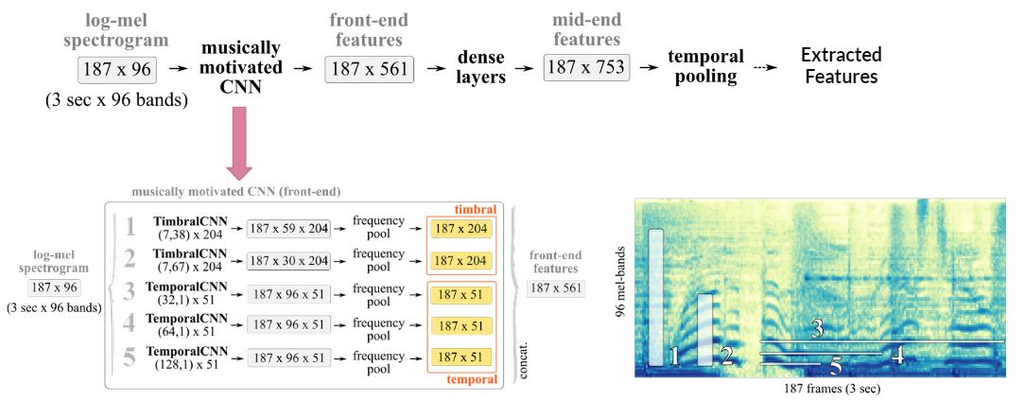

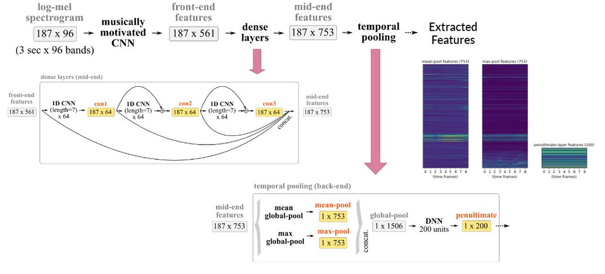

```python
DATASET_NAME = 'gtzan_genre'

dataset = mirdata.initialize(DATASET_NAME, data_home='/content/')
tracks = dataset.load_tracks()
example_track = dataset.choice_track()  # choose a random example track
print(example_track)  # see the available data
```

```
Track(
  audio_path="/content/gtzan_genre/genres/hiphop/hiphop.00056.wav",
  beats_path="/content/gtzan_tempo_beat-main/beats/gtzan_hiphop_00056.beats",
  genre="hip-hop",
  tempo_path="/content/gtzan_tempo_beat-main/tempo/gtzan_hiphop_00056.bpm",
  track_id="hiphop.00056",
  audio: The track's audio

        Returns,
  beats: ,
  tempo: ,
)
```

```python
#Download pre-trained model weights
!curl -SLO https://essentia.upf.edu/models/classifiers/genre_tzanetakis/genre_tzanetakis-musicnn-msd-1.json
!curl -SLO https://essentia.upf.edu/models/classifiers/genre_tzanetakis/genre_tzanetakis-musicnn-msd-1.pb
```

```
  % Total    % Received % Xferd  Average Speed   Time    Time     Time  Current
                                 Dload  Upload   Total   Spent    Left  Speed
100  2092  100  2092    0     0   6599      0 --:--:-- --:--:-- --:--:--  6599
  % Total    % Received % Xferd  Average Speed   Time    Time     Time  Current
                                 Dload  Upload   Total   Spent    Left  Speed
100 3166k  100 3166k    0     0  2543k      0  0:00:01  0:00:01 --:--:-- 2541k
```

```python
MODEL_NAME = 'genre_tzanetakis-musicnn-msd-1'
MODEL_JSON = f'{MODEL_NAME}.json'
MODEL_PB = f'{MODEL_NAME}.pb'

musicnn_metadata = json.load(open(MODEL_JSON, 'r'))
for k, v in musicnn_metadata.items():
    print('{}: {}'.format(k , v))
```

```
name: genre GTZAN
type: multi-class classifier
link: https://essentia.upf.edu/models/classifiers/genre_tzanetakis/genre_tzanetakis-musicnn-msd-1.pb
version: 1
description: classification of music by genre
author: Pablo Alonso
email: pablo.alonso@upf.edu
release_date: 2020-03-31
framework: tensorflow
framework_version: 1.15.0
classes: ['blu', 'cla', 'cou', 'dis', 'hip', 'jaz', 'met', 'pop', 'reg', 'roc']
model_types: ['frozen_model']
dataset: {'name': 'the GTZAN Genre Collection', 'citation': '@article{tzanetakis2002musical,\n  title={Musical genre classification of audio signals},\n  author={Tzanetakis, George and Cook, Perry},\n  journal={IEEE Transactions on speech and audio processing},\n  volume={10},\n  number={5},\n  page…
schema: {'inputs': [{'name': 'model/Placeholder', 'type': 'float', 'shape': [187, 96]}], 'outputs': [{'name': 'model/Sigmoid', 'type': 'float', 'shape': [1, 10], 'op': 'Sigmoid'}, {'name': 'model/dense_2/BiasAdd', 'type': 'float', 'shape': [1, 10], 'op': 'fully connected', 'description': 'logits'}, …
citation: @article{alonso2020tensorflow,
title={TensorFlow Audio Models in Essentia},
author={Alonso-Jim{\'e}nez, Pablo and Bogdanov, Dmitry and Pons, Jordi and Serra, Xavier},
journal={ICASSP 2020},
year={2020}
}
```

```python
MUSICNN_SR = 16000 #We will fix sample rate at 16 kHz as it is required for the input of MusiCNN model.
def extract_mean_embedding(filename):
  """
  Extract mean-temporal embedding from audio contained in filename

  Args:
    filename (str): Name of the audio file

  Return:
    Mean embedding of the song
  """

  # Load audiofile with essentia monoloader to resample the audios to the necessary sample rate in MusiCNN model
  audio = es.MonoLoader(filename=filename, sampleRate=MUSICNN_SR)()

  # Extract the embedding
  musicnn_emb = es.TensorflowPredictMusiCNN(graphFilename=MODEL_PB, output='model/dense/BiasAdd')(audio)

  # Compute mean-embedding across the frames
  mean_emb = np.mean(musicnn_emb, axis=0)
  mean_emb = mean_emb[np.newaxis, :]  # Each song is a 1x200 row vector

  return mean_emb
```

```python
# This step may last several minutes
embeddings = np.zeros((1000, 200))  # N songs x 200 embedding-dim

for i, track in enumerate(tracks.values()):
  if track.genre in ['reggae','rock','blues','classical','country','disco','hiphop','jazz','metal','pop']:
    embeddings[i, :] = extract_mean_embedding(track.audio_path)
```

```python
label_encoder = preprocessing.LabelEncoder()
label_encoder.fit(list({x.genre for x in tracks.values()}))
label_encoder.classes_
```

```
array(['blues', 'classical', 'country', 'disco', 'hip-hop', 'jazz',
       'metal', 'pop', 'reggae', 'rock'], dtype='<U9')
```

```python
labels = []
labels_decoded = []
track_ids = []

for i, (track_id, track) in enumerate(tracks.items()):
  print(f"{i+1}/{len(tracks)}", end="\r")
  labels.append(int(label_encoder.transform([track.genre])[0]))
  labels_decoded.append(track.genre)
  track_ids.append(track_id)

with open('embeddings.npy', 'wb') as f:
    np.save(f, embeddings)
with open('labels.npy', 'wb') as f:
    np.save(f, labels)
with open('labels_decoded.npy', 'wb') as f:
    np.save(f, labels_decoded)
with open('track_ids.npy', 'wb') as f:
    np.save(f, track_ids)
```

#### Final Model training and results

```python
class GenreDataset(Dataset):
  def __init__(self, embeddings, labels):
    # Initialization
    self.embeddings = embeddings
    self.labels = labels

  def __len__(self):
    # Denotes the total number of samples
    return len(self.labels)

  def __getitem__(self, index):
    # Generates one sample of data
    X = torch.from_numpy(self.embeddings[index, :].flatten())
    y = int(self.labels[index])

    return X, y
```

```python
with open('/content/embeddings.npy', 'rb') as f:
    embeddings = np.load(f)
with open('/content/labels.npy', 'rb') as f:
    labels = np.load(f)
with open('/content/labels_decoded.npy', 'rb') as f:
    labels_decoded = np.load(f)
with open('/content/track_ids.npy', 'rb') as f:
    track_ids = np.load(f)

genres = {genre_id: genre for genre_id, genre in zip(labels, labels_decoded)}
```

```python
dataset = GenreDataset(embeddings, labels)
```

```python
BATCH_SIZE = 32

# Split using shuffled indexes
dataset_indices = list(range(len(dataset)))
np.random.shuffle(dataset_indices)
n_test = int(np.floor(0.2 * len(dataset)))
train_idx, test_idx = dataset_indices[n_test:], dataset_indices[:n_test]

train_sampler = SubsetRandomSampler(train_idx)
test_sampler = SubsetRandomSampler(test_idx)

# Data Loaders
train_loader = DataLoader(dataset=dataset, shuffle=False, batch_size=BATCH_SIZE, sampler=train_sampler)
test_loader = DataLoader(dataset=dataset, shuffle=False, batch_size=BATCH_SIZE, sampler=test_sampler)
```

##### Simple MLP Model

```python
class MLP(nn.Module):
  '''
    Multilayer Perceptron.
  '''
  def __init__(self, input_size, hidden_size, output_size):
    super().__init__()
    self.input_size = input_size
    self.hidden_size  = hidden_size
    self.output_size  = output_size

    net = nn.Sequential(
      nn.Linear(self.input_size, self.hidden_size),
      nn.ReLU(),
      nn.Linear(self.hidden_size, self.output_size)
    )

    if using_gpu:
      self.layers = net.cuda()
    else:
      self.layers = net

  def forward(self, x):
    '''Forward pass'''
    return self.layers(x)
```

```python
using_gpu = False
# Initialize the MLP
mlp = MLP(200, 100, len(genres))

loss_function = nn.CrossEntropyLoss()
optimizer = torch.optim.Adam(mlp.parameters(), lr=1e-3)

N_epochs = 30
mlp.train()

for epoch in range(0, N_epochs):
  train_loss = 0.0    # Set current loss value

  for i, data in enumerate(train_loader):
    inputs, targets = data
    if using_gpu:
      inputs, targets = inputs.cuda(), targets.cuda()

    optimizer.zero_grad()
    outputs = mlp(inputs.float())
    loss = loss_function(outputs, targets.long())
    loss.backward()
    optimizer.step()
    train_loss += loss.item()

  if epoch%5==4:
    print(f'Epoch {epoch+1} - Training Loss: {train_loss}')

print('Training process has finished.')
```

```
Epoch 5 - Training Loss: 3.4760907869786024
Epoch 10 - Training Loss: 2.9554486982524395
Epoch 15 - Training Loss: 1.7753180377185345
Epoch 20 - Training Loss: 1.921421348117292
Epoch 25 - Training Loss: 0.7786602331325412
Epoch 30 - Training Loss: 0.6043105336138979
Training process has finished.
```

```python
class_correct = list(0. for i in range(10))
class_total = list(0. for i in range(10))
correct = 0
total = 0

y_test = []
y_test_predicted = []

mlp.eval()
for data in test_loader:
    inputs, targets = data
    if using_gpu:
      inputs, targets = inputs.cuda(), targets.cuda()

    outputs = mlp(inputs.float())
    _, predicted = torch.max(outputs, 1)

    y_test.extend(list(targets.cpu().numpy()))
    y_test_predicted.extend(list(predicted.cpu().numpy()))

    total += targets.size(0)
    correct += (predicted == targets).sum().item()

    c = (predicted == targets).squeeze()
    for i in range(len(targets)):
      label = targets[i]
      class_correct[label] += c[i].item()
      class_total[label] += 1

print('Test process has finished.')
```

```
Test process has finished.
```

```python
print(f"Global accuracy: {100 * correct / total :.2f}%")
print("\nAccuracy by genre:")
for i, genre in genres.items():
    print(f"- {genre}: {100 * class_correct[i] / class_total[i] :.2f}%")
```

```
Global accuracy: 94.00%

Accuracy by genre:
- classical: 96.55%
- country: 100.00%
- disco: 94.44%
- hip-hop: 91.67%
- jazz: 100.00%
- rock: 91.30%
- blues: 95.83%
- reggae: 87.50%
- pop: 87.50%
- metal: 94.12%
```

```python
labels_test = np.array([genres[v] for v in y_test])
labels_test_predicted = np.array([genres[v] for v in y_test_predicted])
```

```python
genres_set = list(genres.values())

cm = confusion_matrix(labels_test, labels_test_predicted, labels=genres_set)
cm_text = [[str(y) for y in x] for x in cm]

# set up figure
fig = ff.create_annotated_heatmap(cm, x=genres_set, y=genres_set, annotation_text=cm_text, colorscale='Blues')
fig.update_layout(title_text='<i><b>Confusion matrix</b></i>')
fig.update_layout(margin=dict(t=100, l=200, r=200),
                  xaxis = dict(title='Predicted genre'),
                  yaxis = dict(title='Real genre'))


#fig['layout']['xaxis']['autorange'] = "reversed"
fig['data'][0]['showscale'] = True  # add colorbar
fig.show()
```

[interactive chart not shown]

#### RNN Model

```python
class RNN(nn.Module):
    def __init__(self, input_size, hidden_size, num_layers, num_classes):
        super(RNN, self).__init__()
        self.num_layers = num_layers
        self.hidden_size = hidden_size
        self.lstm = nn.LSTM(input_size, hidden_size, num_layers, dropout=0.4)
        self.fc1 = nn.Linear(hidden_size, hidden_size)
        self.relu = nn.ReLU()
        self.fc = nn.Linear(hidden_size, num_classes)

    def forward(self, x):
        x = x.unsqueeze(0)
        # print("Input Shape",x.shape)
        h0 = Variable(torch.zeros(self.num_layers, x.size(1), self.hidden_size).float()).cuda()
        c0 = Variable(torch.zeros(self.num_layers, x.size(1), self.hidden_size).float()).cuda()
        # print("Initial state shape:",h0.shape)
        out, _ = self.lstm(x, (h0, c0))
        # print("LSTM Output Shape:",out.shape)
        # out = self.relu(self.fc1(out[:, -1, :]))
        out = self.fc(out)
        return out
```

```python
def get_accuracy(model, data_loader):
    correct, total = 0, 0
    for audio, labels in data_loader:
        if use_cuda and torch.cuda.is_available():
            audio = audio.cuda()
            labels = labels.cuda()
        output = model(audio.float()).squeeze(0)
        pred = output.max(1, keepdim=True)[1]
        correct += pred.eq(labels.view_as(pred)).sum().item()
        total += labels.shape[0]
    return correct / total
```

```
Training on Cuda
```

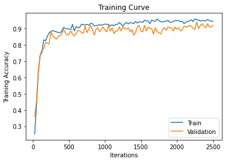

```
Training process has finished.
```

```python
use_cuda = True
rnn = RNN(input_size=200, hidden_size=30, num_layers=2, num_classes=10)
if use_cuda and torch.cuda.is_available():
  print("Training on Cuda")
  rnn.cuda()

loss_function = nn.CrossEntropyLoss()
optimizer = torch.optim.Adam(rnn.parameters(), lr=1e-3)

N_epochs = 100
rnn.train()

iters, train_acc, valid_acc = [], [], []
n = 0
for epoch in range(0, N_epochs):
  train_loss = 0.0    # Set current loss value

  for i, data in enumerate(train_loader):
    inputs, targets = data
    if use_cuda:
      inputs, targets = inputs.cuda(), targets.cuda()

    optimizer.zero_grad()
    outputs = rnn(inputs.float()).squeeze(0)
    loss = loss_function(outputs, targets.long())
    loss.backward()
    optimizer.step()
    train_loss += loss.item()
    n+=1
  train_acc.append(get_accuracy(rnn, train_loader))
  valid_acc.append(get_accuracy(rnn, test_loader))
  iters.append(n)


plt.title("Training Curve")
plt.plot(iters, train_acc, label="Train")
plt.plot(iters, valid_acc, label="Validation")
plt.xlabel("Iterations")
plt.ylabel("Training Accuracy")
plt.legend(loc='best')
plt.show()
  # if epoch%5==4:
  #   print(f'Epoch {epoch+1} - Training Loss: {train_loss}')
  #   model_path = "{}_epoch_{}".format('rnn',epoch+1)
  #   torch.save(rnn, model_path)

print('Training process has finished.')
```

```python
class_correct = list(0. for i in range(10))
class_total = list(0. for i in range(10))
correct = 0
total = 0

y_test = []
y_test_predicted = []

rnn.eval()
for data in test_loader:
    inputs, targets = data
    if use_cuda:
      inputs, targets = inputs.cuda(), targets.cuda()

    outputs = rnn(inputs.float()).squeeze(0)
    _, predicted = torch.max(outputs, 1)

    y_test.extend(list(targets.cpu().numpy()))
    y_test_predicted.extend(list(predicted.cpu().numpy()))

    total += targets.size(0)
    # print(predicted.shape)
    # print(targets.shape)
    correct += (predicted == targets).sum().item()

    c = (predicted == targets).squeeze()
    for i in range(len(targets)):
      label = targets[i]
      class_correct[label] += c[i].item()
      class_total[label] += 1

print('Test process has finished.')
```

```
Test process has finished.
```

```python
labels_test = np.array([genres[v] for v in y_test])
labels_test_predicted = np.array([genres[v] for v in y_test_predicted])
```

```python
print(f"Global accuracy: {100 * correct / total :.2f}%")
print("\nAccuracy by genre:")
for i, genre in genres.items():
    print(f"- {genre}: {100 * class_correct[i] / class_total[i] :.2f}%")
```

```
Global accuracy: 94.00%

Accuracy by genre:
- classical: 100.00%
- country: 100.00%
- disco: 88.89%
- hip-hop: 100.00%
- jazz: 90.91%
- rock: 86.96%
- blues: 95.83%
- reggae: 93.75%
- pop: 87.50%
- metal: 88.24%
```

```python
genres_set = list(genres.values())

cm = confusion_matrix(labels_test, labels_test_predicted, labels=genres_set)
cm_text = [[str(y) for y in x] for x in cm]

# set up figure
fig = ff.create_annotated_heatmap(cm, x=genres_set, y=genres_set, annotation_text=cm_text, colorscale='Blues')
fig.update_layout(title_text='<i><b>Confusion matrix</b></i>')
fig.update_layout(margin=dict(t=100, l=200, r=200),
                  xaxis = dict(title='Predicted genre'),
                  yaxis = dict(title='Real genre'))


#fig['layout']['xaxis']['autorange'] = "reversed"
fig['data'][0]['showscale'] = True  # add colorbar
fig.show()
```

[interactive chart not shown]

Even though both the simple MLP and RNN model produced similar prediction accuracies, the RNN is chosen as the final model as from the confusion matrix it can be seen that it handles the miss-classifications better. Even when it predicts incorrectly, the genre predicted is very similar to the true genre.

### Testing on New Data

The flask app deployed with this testing can be found in the following notebook and is also attached with the zip folder.

https://colab.research.google.com/drive/1IxbEgtpgyMk0AsNoTT5xRon3bX9njaDK?usp=sharing

```python
%%shell
jupyter nbconvert --to html /content/Music_Genre_Detection_Final_Report.ipynb
```

```
[NbConvertApp] Converting notebook /content/Music_Genre_Detection_Final_Report.ipynb to html
[NbConvertApp] Writing 1862926 bytes to /content/Music_Genre_Detection_Final_Report.html
```